# Méthodes de Partionnement et d'apprentissage non supervisé

Classification Hiérarchique et Kmeans

Anne Badel, Frédéric Guyon & Jacques van Helden

2019-02-20

# Partitionnement et apprentissage

- On a une **représentation** des données
  - sous forme de valeurs réelles=vecteur de
  - sous forme de catégories
- **Clustering**: on cherche a priori des groupes dans les données
- **Apprentissage**:
  - on connaît le partitionnement sur un jeu de données
  - on cherche le groupe (la classe) de nouvelles données

# Partionnement = Clustering

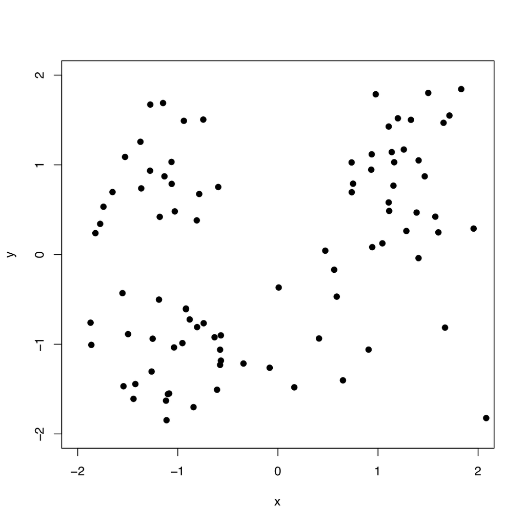

Y a-t-il des groupes ?

# Partionnement = Clustering

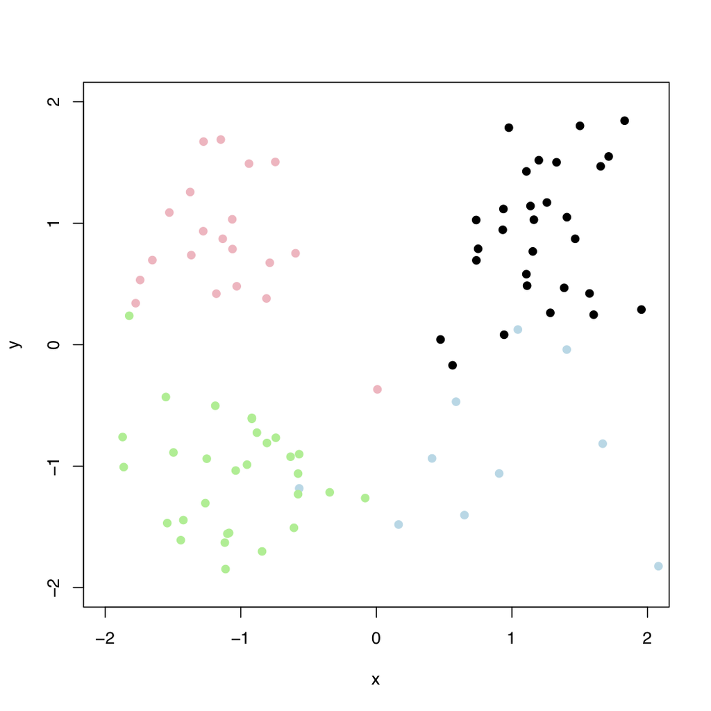

Oui, 4 groupes.

# Apprentissage

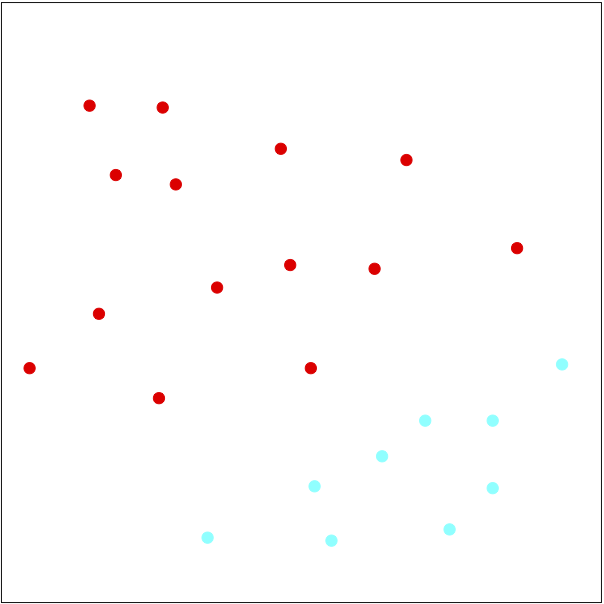

2 groupes.

# Apprentissage: Séparation linéaire

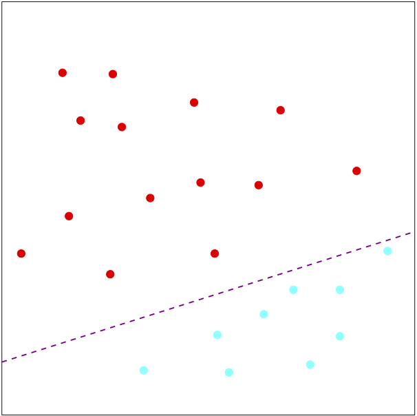

2 groupes.

# Méthodes

Trois grands principes de méthodes basées sur:

- La géométrie
- Les probabilités (statistique)
- Les graphes

En fait, trois façons de voir les mêmes algorithmes

# Géométrie et distances

On considère les données comme des points de $R^n$ (*)

- géométrie donnée par distances
- distances = dissimilaritées imposées par le problème
- dissimilarités $\longrightarrow$ permettent visualisation de l'ensemble des points
- Détermination visuelle des groupes

(*) Espace Euclidien à $n$ dimensions, où

- chaque dimension représente une des variables observées;
- un individu est décrit comme un vecteur à $n$ valeurs, qui correspond à un point dans cet espace.

# Les données

[Ces données sont un classique des méthodes d'apprentissage](https://onlinelibrary.wiley.com/doi/epdf/10.1111/j.1469-1809.1936.tb02137.x)

Dans un premier temps, regardons les données.

```r
dim(mes.iris)
```

```
[1] 150   4
```

```r
head(mes.iris)
```

```
  Sepal.Length Sepal.Width Petal.Length Petal.Width
1          5.1         3.5          1.4         0.2
2          4.9         3.0          1.4         0.2
3          4.7         3.2          1.3         0.2
4          4.6         3.1          1.5         0.2
5          5.0         3.6          1.4         0.2
6          5.4         3.9          1.7         0.4
```

# Les variables

```r
summary(mes.iris)
```

```
  Sepal.Length    Sepal.Width     Petal.Length    Petal.Width
 Min.   :4.300   Min.   :2.000   Min.   :1.000   Min.   :0.100
 1st Qu.:5.100   1st Qu.:2.800   1st Qu.:1.600   1st Qu.:0.300
 Median :5.800   Median :3.000   Median :4.350   Median :1.300
 Mean   :5.843   Mean   :3.057   Mean   :3.758   Mean   :1.199
 3rd Qu.:6.400   3rd Qu.:3.300   3rd Qu.:5.100   3rd Qu.:1.800
 Max.   :7.900   Max.   :4.400   Max.   :6.900   Max.   :2.500
```

# Visualisation des données

On peut ensuite essayer de visualiser les données

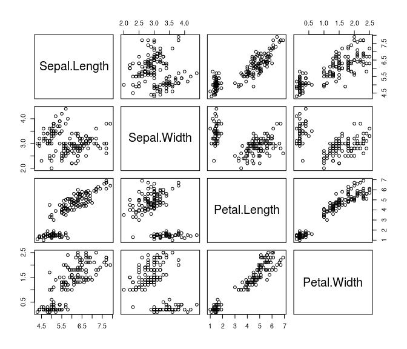

```r
plot(mes.iris)
```

# Cas d'étude : TCGA Breast Invasive Cancer (BIC)

# TP : analyse de données d'expression

# Géométrie et distances

Sur la base d'une distance (souvent euclidienne)

- Partionnement:
  - Moyennes mobiles ou K-means : séparation optimale des groupes connaissant le nombre de groupes
  - Méthode agglomérative ouhierarchical clustering
- Classification:
  - attribution K plus proches voisins (K Nearest Neighbor)
  - séparation linéaire ou non linéaire

# Distances

Définition d'une distance : fonction positive de deux variables

1. $d(x,y) \ge 0$
2. $d(x,y) = d(y,x)$
3. $d(x,y) = 0 \Longleftrightarrow x = y$
4. **Inégalité triangulaire :** $d(x,z) \le$ d(x,y)+d(y,z)

Si 1,2,3 : dissimilarité

# Distances utilisées dans R

- distance euclidienne ou distance $L_2$: $d(x,y)=\sqrt{\sum_i (x_i-y_i)^2}$
- distance de manahattan ou distance $L_1$: $d(x,y)=\sum_i |x_i-y_i|$
- distance du maximum ou L-infinis, $L_\infty$: $d(x,y)=\max_i |x_i-y_i|$

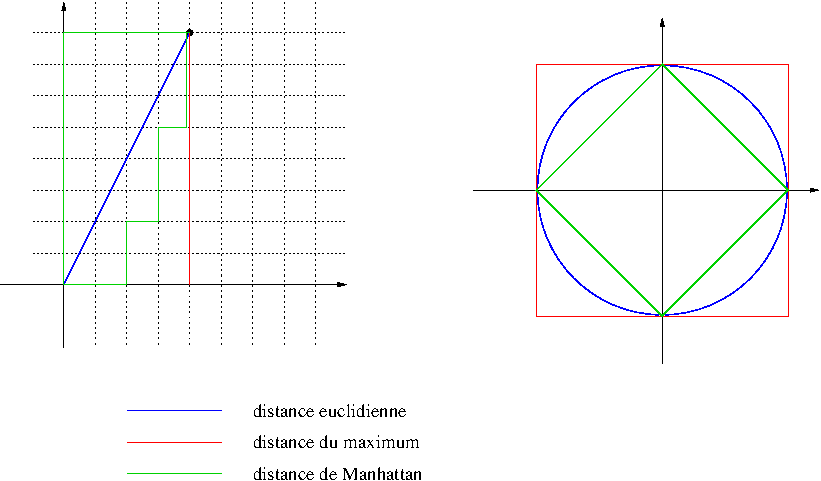

# Distances utilisées dans R

- distance de Minkowski $l_p$:
  $$d(x,y)=\sqrt[p]{\sum_i (|x_i-y_i|^p}$$
- distance de Canberra (x et y valeurs positives):
  $$d(x,y)=\sum_i \frac{x_i-y_i}{x_i+y_i}$$
- distance binaire ou distance de Jaccard ou Tanimoto: proportion de propriétés communes

# Autres distances non géométriques (pour information)

Utilisées en bio-informatique:

- Distance de **Hamming**: nombre de remplacements de caractères (substitutions)
- Distance de **Levenshtein**: nombre de substitutions, insertions, deletions entre deux chaînes de caractères

$$d("BONJOUR", "BONSOIR")=2$$

- Distance d'**alignements**: distances de Levenshtein avec poids (par ex. matrices BLOSSUM)
- Distances d'**arbre** (Neighbor Joining)
- Distances **ultra-métriques** (phylogénie UPGMA)

# Distances plus classiques en génomique

Comme vu lors de la séance 3, il existe d'autres mesures de distances :

- **Jaccard** (comparaison d'ensembles): $J_D = \frac{A \cap B}{A \cup B}$
- Distance du $\chi^2$ (comparaison de tableau d'effectifs)

Ne sont pas des distances, mais indices de dissimilarité :

- **Bray-Curtis** (en écologie, comparaison d'abondance d'espèces)
- **Jensen-Shannon** (comparaison de distributions)

**Remarque** : lors du TP, sur les données d'expression RNA-seq, nous utiliserons le **coefficient de corrélation de Spearman** et la distance dérivée, $d_c = 1-r$

# Distances entre groupes

- **Single linkage** : élements les plus proches des 2 groupes

$$D(C_1,C_2) = \min_{i \in C_1, j \in C_2} D(x_i, x_j)$$

- **Complete linkage** : éléments les plus éloignés des 2 groupes

$$D(C_1,C_2) = \max_{i \in C_1, j \in C_2} D(x_i, x_j)$$

- **Group average** : distance moyenne

$$D(C_1,C_2) = \frac{1}{N_1 N_2} \sum_{i \in C_1, j \in C_2} D(x_i, x_j)$$

- **Ward**

$d^2(C_i,C_j) = I_{intra}(C_i \cup C_j)-I_{intra}(C_i)-I_{intra}(C_j)$

$D(C_1,C_2) = \sqrt{\frac{N_1N_2}{N_1 + N_2}} \| m_1 -m_2 \|$

# Distances entre groupes

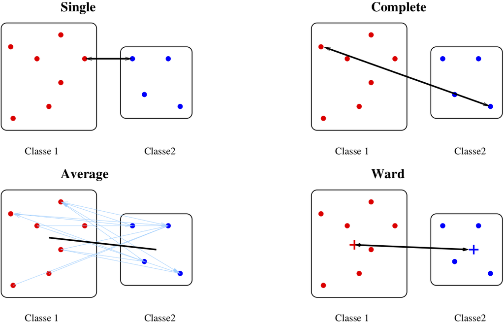

# Les données

[Ces données sont un classique des méthodes d'apprentissage](https://onlinelibrary.wiley.com/doi/epdf/10.1111/j.1469-1809.1936.tb02137.x)

Dans un premier temps, regardons les données

```r
dim(mes.iris)
```

```
[1] 150   4
```

```r
head(mes.iris)
```

```
  Sepal.Length Sepal.Width Petal.Length Petal.Width
1          5.1         3.5          1.4         0.2
2          4.9         3.0          1.4         0.2
3          4.7         3.2          1.3         0.2
4          4.6         3.1          1.5         0.2
5          5.0         3.6          1.4         0.2
6          5.4         3.9          1.7         0.4
```

```r
str(mes.iris)
```

```
'data.frame':   150 obs. of  4 variables:
 $ Sepal.Length: num  5.1 4.9 4.7 4.6 5 5.4 4.6 5 4.4 4.9 ...
 $ Sepal.Width : num  3.5 3 3.2 3.1 3.6 3.9 3.4 3.4 2.9 3.1 ...
 $ Petal.Length: num  1.4 1.4 1.3 1.5 1.4 1.7 1.4 1.5 1.4 1.5 ...
 $ Petal.Width : num  0.2 0.2 0.2 0.2 0.2 0.4 0.3 0.2 0.2 0.1 ...
```

```r
summary(mes.iris)
```

```
  Sepal.Length    Sepal.Width     Petal.Length    Petal.Width
 Min.   :4.300   Min.   :2.000   Min.   :1.000   Min.   :0.100
 1st Qu.:5.100   1st Qu.:2.800   1st Qu.:1.600   1st Qu.:0.300
 Median :5.800   Median :3.000   Median :4.350   Median :1.300
 Mean   :5.843   Mean   :3.057   Mean   :3.758   Mean   :1.199
 3rd Qu.:6.400   3rd Qu.:3.300   3rd Qu.:5.100   3rd Qu.:1.800
 Max.   :7.900   Max.   :4.400   Max.   :6.900   Max.   :2.500
```

# Visualisation des données

On peut ensuite essayer de visualiser les données

- par un `plot`

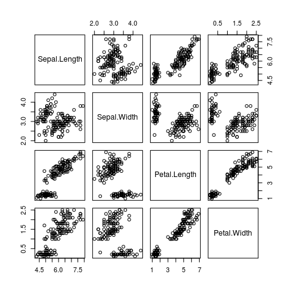

```r
plot(mes.iris)
```

# Visualisation des données - coloration par espèces

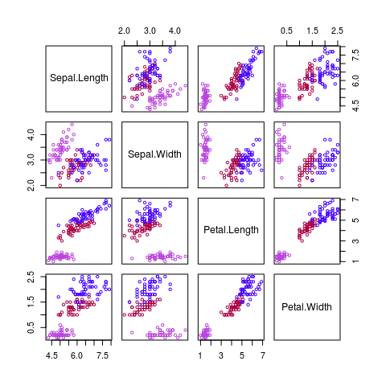

```r
species.colors <- c(setosa = "#BB44DD", virginica = "#AA0044", versicolor = "#4400FF")
plot(mes.iris, col = species.colors[iris$Species], cex = 0.7)
```

# Visualisation des données

- par la fonction `image()`

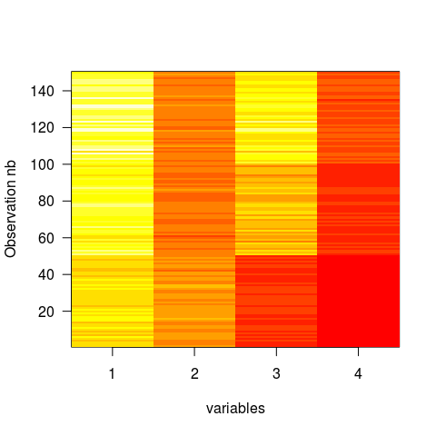

```r
image(1:nb.var, 1:nb.iris ,t(as.matrix(mes.iris)), xlab = "variables", ylab = "Observation nb", las = 1)
```

# Nettoyage des données (1): données manquantes

Avant de commencer à travailler, il est nécessaire de commencer par vérifier que :

- il n'y a pas de données manquantes

```r
sum(is.na(mes.iris))
```

```
[1] 0
```

# Nettoyage des données (2) : variables constantes

- aucune variable n'est constante (aucune variable n'a une variance nulle)

```r
iris.var <- apply(mes.iris, 2, var)
kable(iris.var, digits = 3, col.names = "Variance")
```

|  | Variance |
| --- | --- |
| Sepal.Length | 0.686 |
| Sepal.Width | 0.190 |
| Petal.Length | 3.116 |
| Petal.Width | 0.581 |

```r
sum(apply(mes.iris, 2, var) == 0)
```

```
[1] 0
```

# Normalisation

Afin de pouvoir considérer que toutes les variables sont à la même échelle, il est parfois nécessaire de normaliser les données.

- soit
  - en centrant (ramener la moyenne de chaque variable à $0$)

```r
mes.iris.centre <- scale(mes.iris, center=TRUE, scale=FALSE)
```

- soit
  - en centrant (ramener la moyenne de chaque variable $0$)
  - et mettant à l'échelle (ramener la variance de chaque variable à $1$)

```r
mes.iris.scaled <- scale(mes.iris, center=TRUE, scale=TRUE)
```

# On peut visuellement regarder l'effet de la normalisation :

## par un plot des données

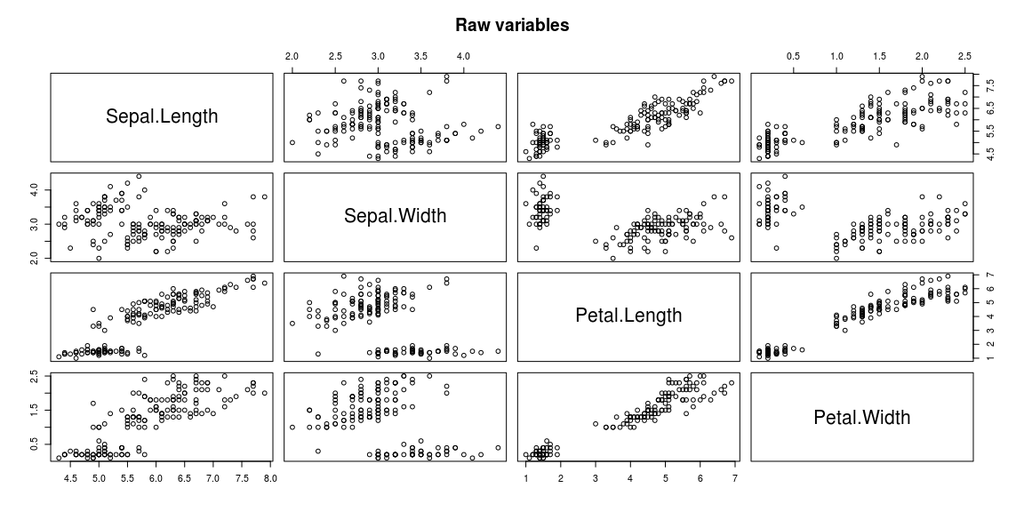

```r
plot(mes.iris, main = "Raw variables")
```

**!** ne pas faire si "grosses" données

## ... par une boîte à moustaches (boxplot)

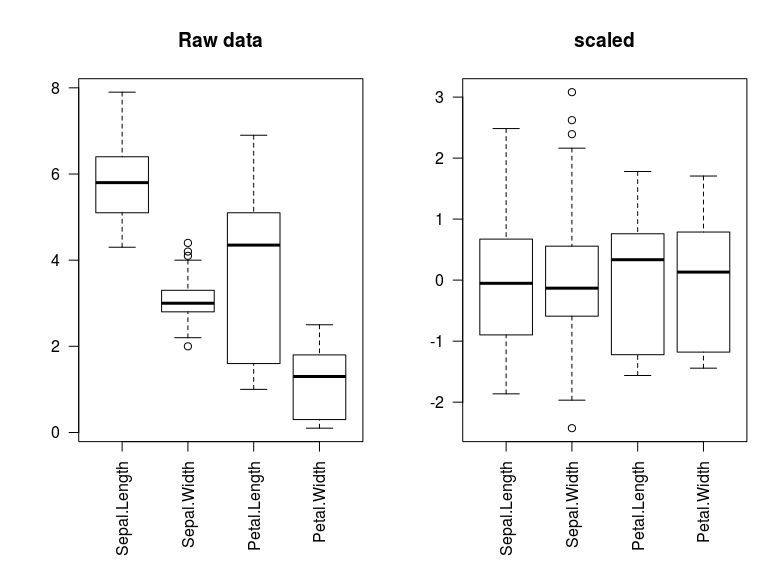

```r
par(mfrow = c(1,2))
par(mar = c(7, 4.1, 4.1, 1.1)) # adapt margin sizes for the labels
boxplot(mes.iris, main = "Raw data", las = 2)
boxplot(mes.iris.scaled, main = "scaled", las = 2)
```

```r
par(mar = c(5.1, 4.1, 4.1, 2.1)) # Restore original margin sizes
```

## ... par une image

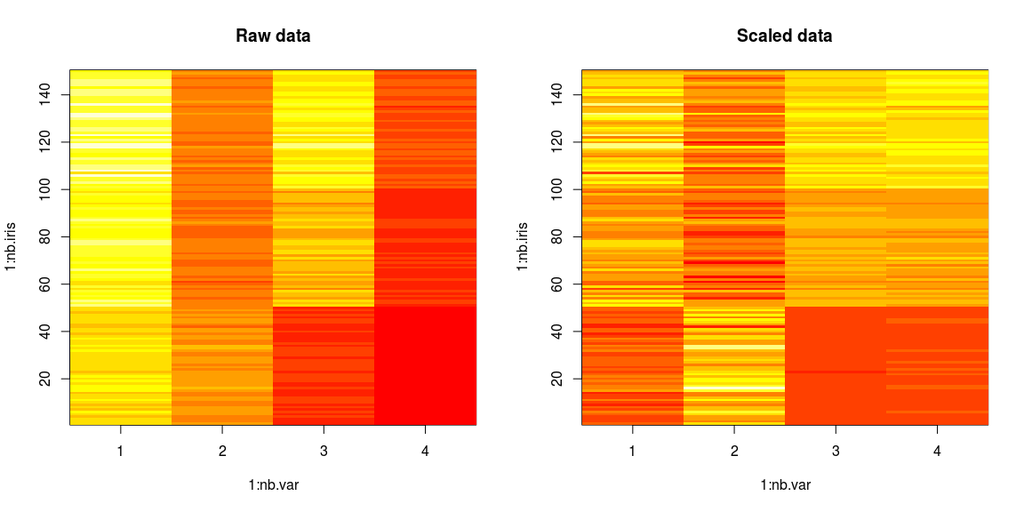

```r
par(mfrow=c(1,2))
image(1:nb.var, 1:nb.iris, t(as.matrix(mes.iris)), main="Raw data")
image(1:nb.var, 1:nb.iris, t(as.matrix(mes.iris.scaled)), main="Scaled data")
```

## ... par une projection sur une ACP

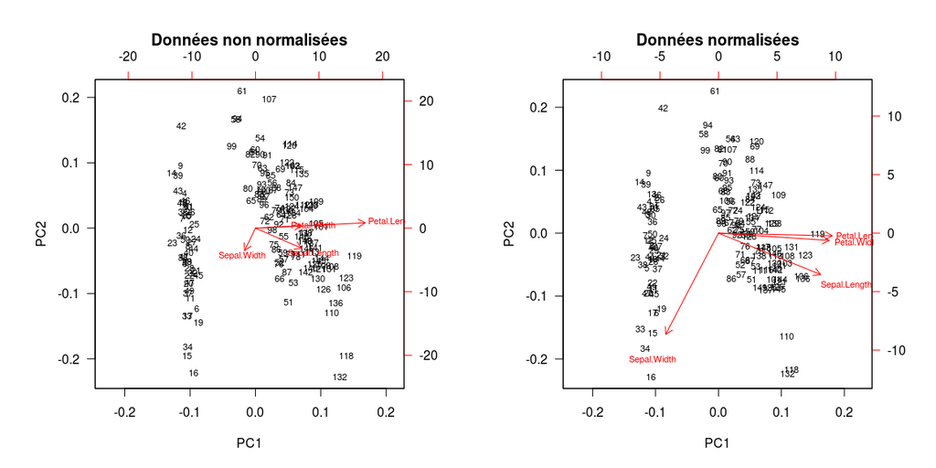

```r
par(mfrow = c(1,2))
biplot(prcomp(mes.iris), las = 1, cex = 0.7,
       main = "Données non normalisées")
biplot(prcomp(mes.iris, scale = TRUE), las = 1, cex = 0.7,
       main = "Données normalisées")
```

# La matrice de distances

Nous utilisons ici la distance euclidienne.

```r
iris.euc <- dist(mes.iris)
iris.scale.euc <- dist(mes.iris.scaled)
```

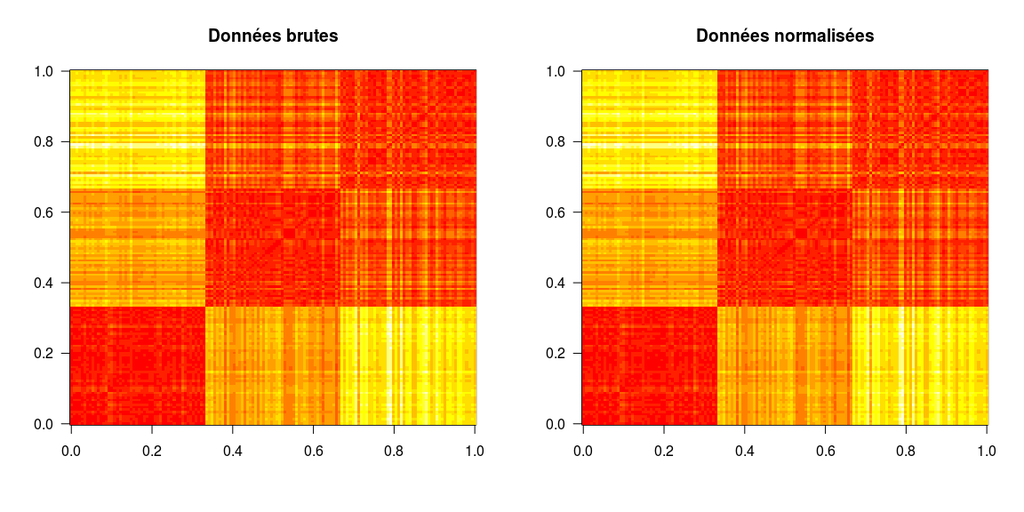

```r
par(mfrow = c(1,2))
image(t(as.matrix(iris.euc)), main = "Données brutes", las = 1)
image(t(as.matrix(iris.scale.euc)), main = "Données normalisées", las = 1)
```

```r
par(mfrow = c(1,1))
```

# La classification hiérarchique

## Principe

- **classification hiérarchique** : mettre en évidence des liens hiérachiques entre les individus
  - classification hiérarchique **ascendante** : partir des individus pour arriver à des classes / cluster
  - classification hiérarchique **descendante** : partir d'un groupe qu'on subdivise en sous-groupes /clusters jusqu'à arriver à des individus.

## Notion importante, cf distances

- ressemblance entre individus = distance
- ressemblance entre groupes d'invidus = critère d'aggrégation
  - lien simple
  - lien complet
  - lien moyen
  - critère de Ward

## L'algorithme

### étape 1 :

- départ : n individus = n clusters distincts
- calcul des distances entre tous les individus
  - choix de la métrique à utiliser en fonction du type de données
- regroupement des 2 individus les plus proches => (n-1) clusters

## au départ

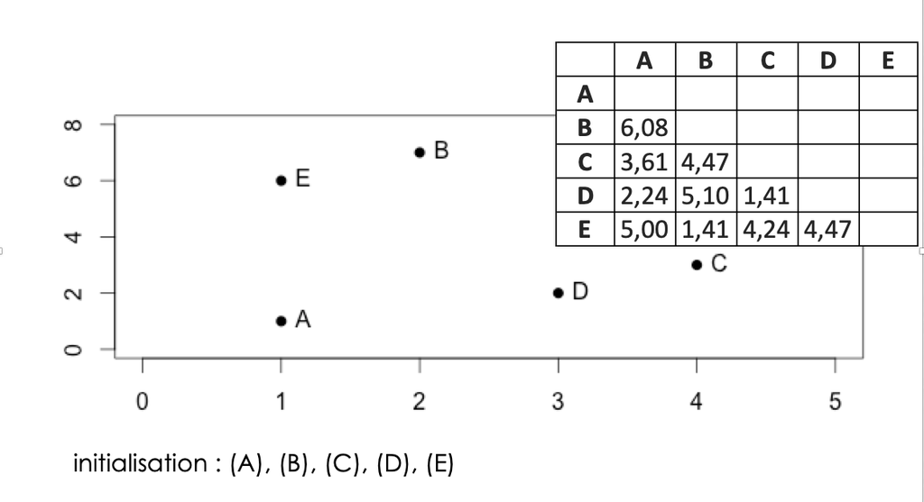

## identification des individus les plus proches

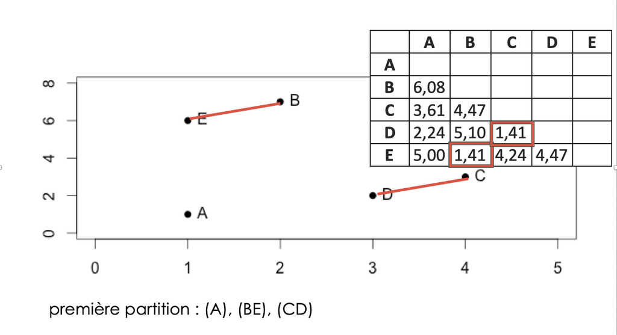

## construction du dendrogramme

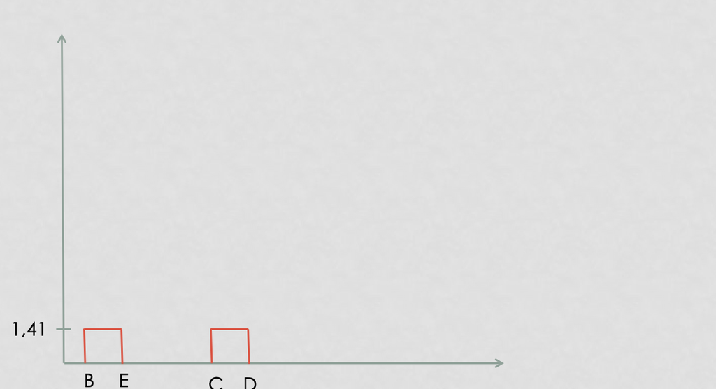

## étape j :

- calcul des dissemblances entre chaque groupe obtenu à l'étape $(j-1)$
- regroupement des deux groupes les plus proches => $(n-j)$ clusters

## calcul des nouveaux représentants 'BE' et 'CD'

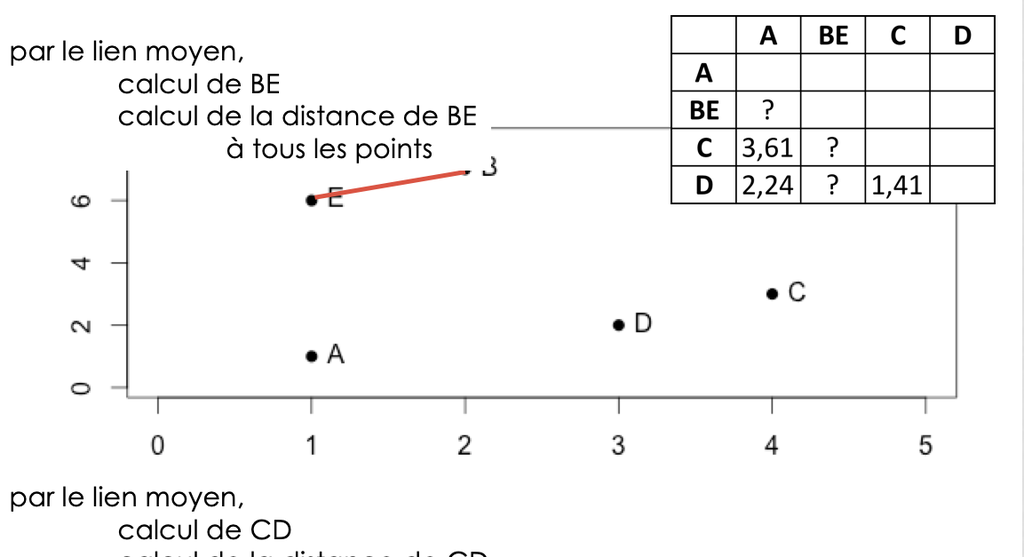

## calcul des distances de l'individu restant 'A' aux points moyens

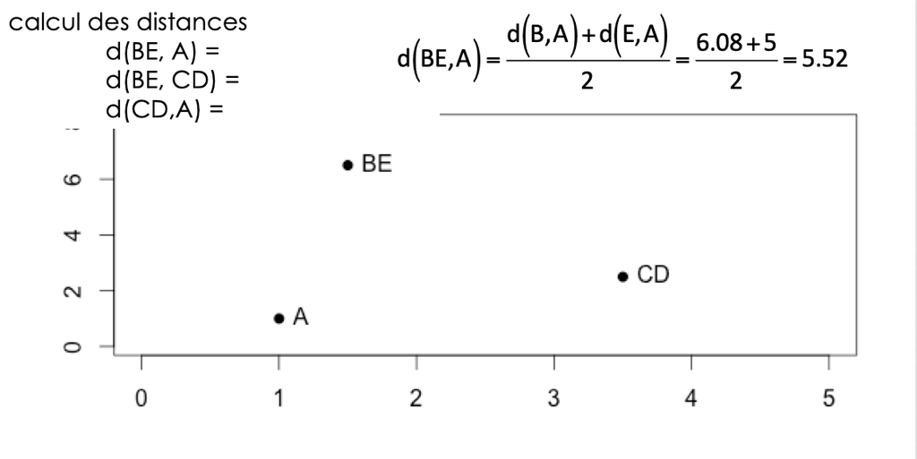

## A est plus proche de ...

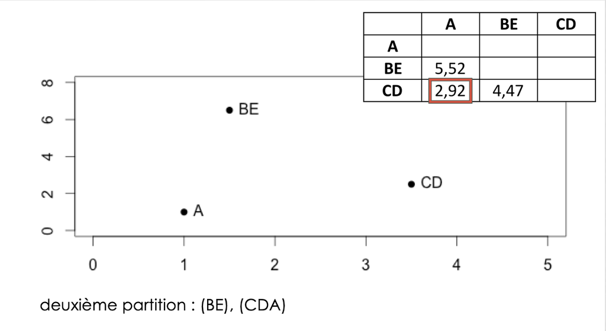

## dendrogramme

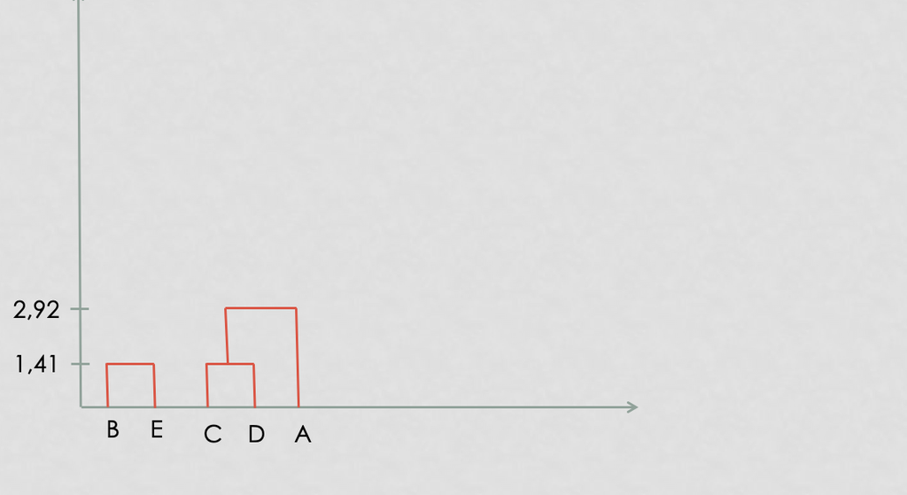

## pour finir

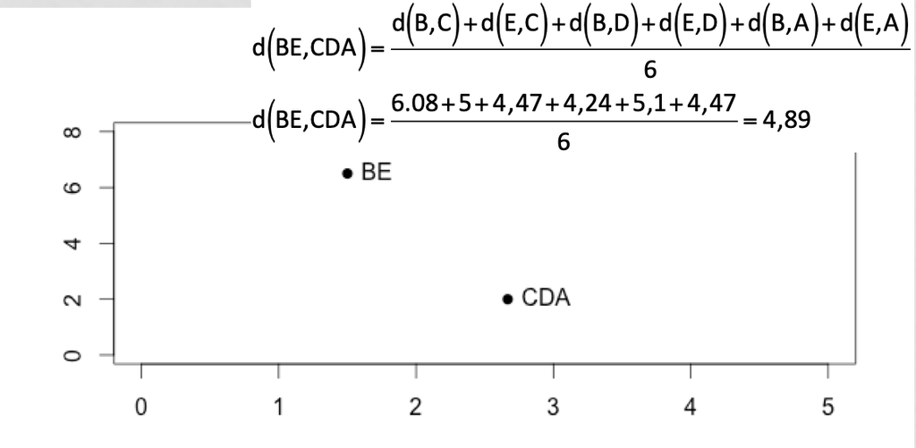

- à l'étape $(n-1)$, tous les individus sont regroupés dans un même cluster

## dendrogramme final

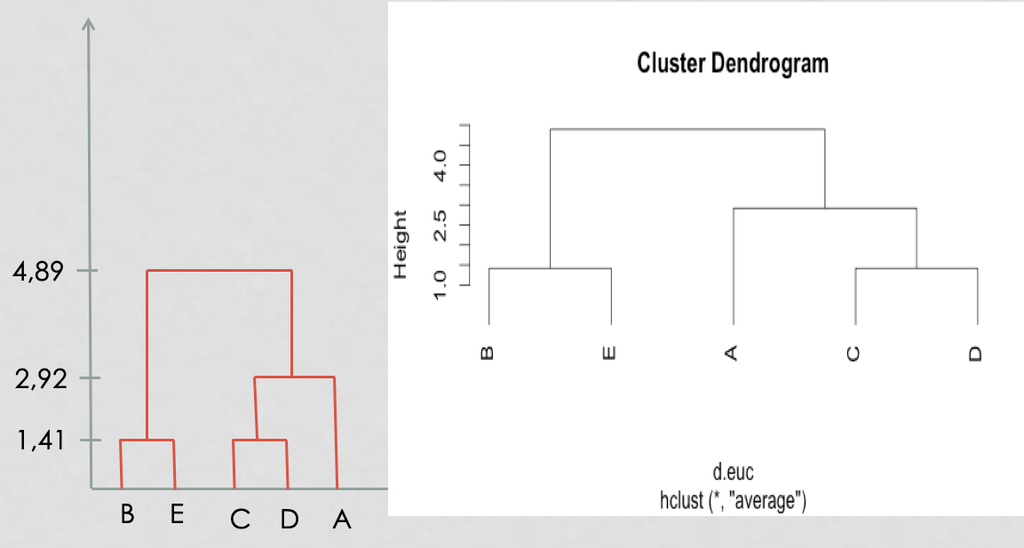

## Je ne fais pas attention à ce que je fais ...

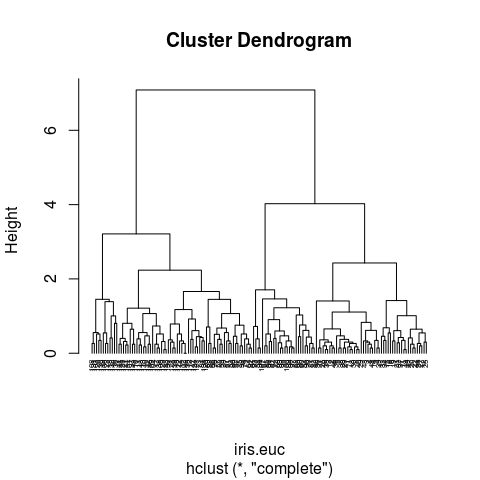

```r
iris.hclust <- hclust(iris.euc)
plot(iris.hclust, hang = -1, cex = 0.5)
```

... c'est à dire aux options des fonctions `dist()` et `hclust()`

## Sur données normalisées

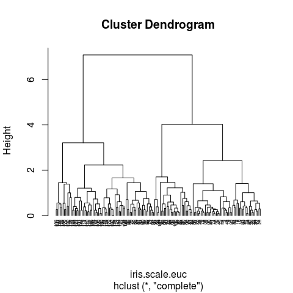

```r
iris.scale.hclust <- hclust(iris.scale.euc)
plot(iris.scale.hclust, hang = -1, cex = 0.5)
```

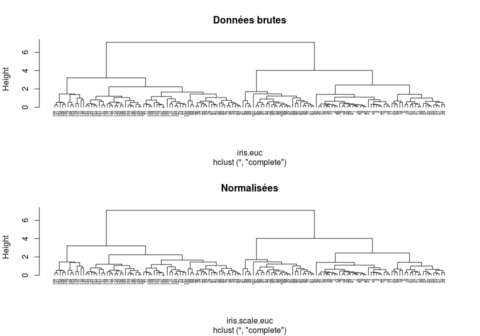

```r
par(mfrow = c(2, 1))
plot(iris.hclust, hang = -1, cex = 0.5, main = "Données brutes")
plot(iris.scale.hclust, hang = -1, cex = 0.5, main = "Normalisées")
```

## En utilisant une autre métrique

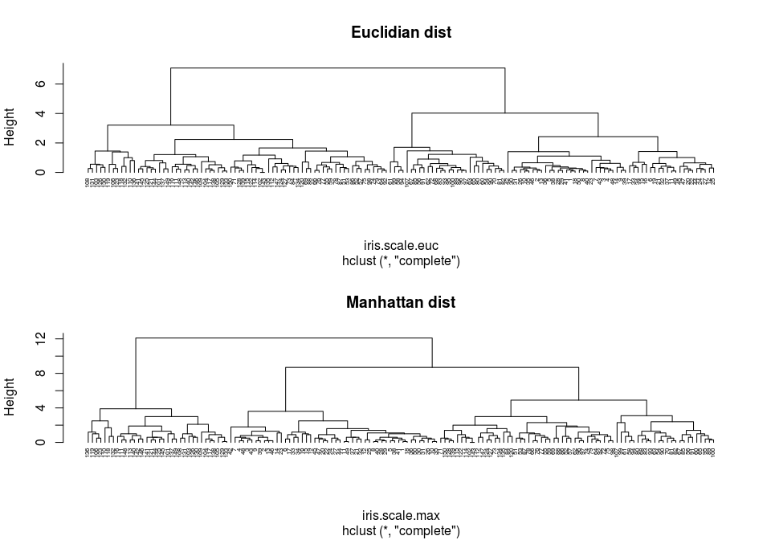

```r
iris.scale.max <- dist(mes.iris.scaled, method = "manhattan")
iris.scale.hclust.max <- hclust(iris.scale.max)
par(mfrow=c(2,1))
plot(iris.scale.hclust, hang=-1, cex=0.5, main = "Euclidian dist")
plot(iris.scale.hclust.max, hang=-1, cex=0.5, main = "Manhattan dist")
```

## En utilisant un autre critère d'aggrégation

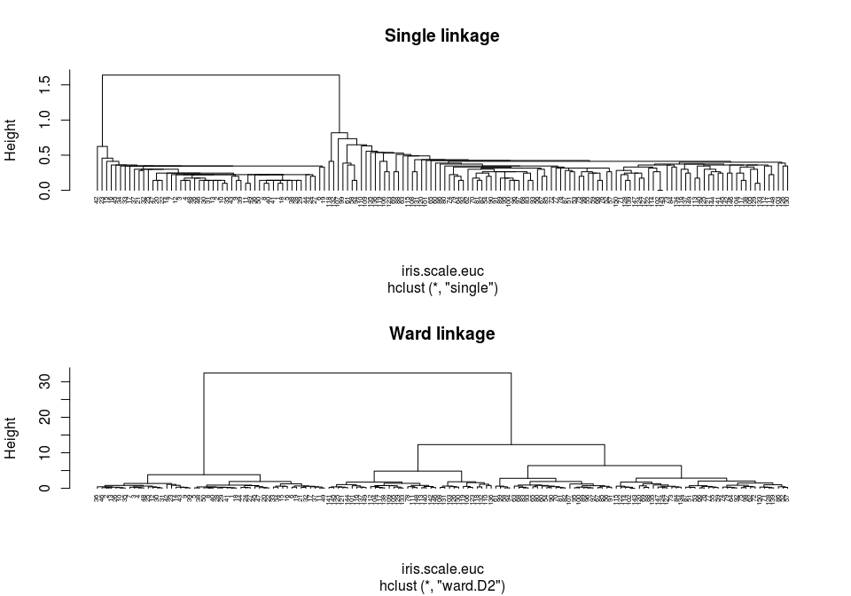

```r
iris.scale.hclust.single <- hclust(iris.scale.euc, method="single")
iris.scale.hclust.ward <- hclust(iris.scale.euc, method="ward.D2")
par(mfrow=c(2,1))
plot(iris.scale.hclust.single, hang=-1, cex=0.5, main = "Single linkage")
plot(iris.scale.hclust.ward, hang=-1, cex=0.5, main = "Ward linkage")
```

```r
par(mfrow=c(1,1))
```

# Les k-means

Les individus dans le plan

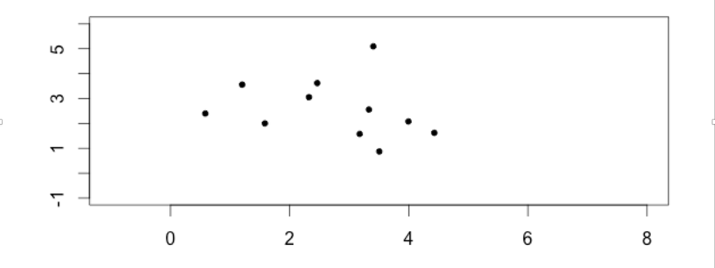